# ANA 515 Assignment 4

Dongyoon Lee

October 16th, 2022

## Business Problem and Goal

The goal of this project is to segment mall customers on their age, gender, interest, etc. Customer segmentation is an important tool in the field of business to better understand customers and apply customized marketing.

## Data Source

The source data was retrieved from https://www.kaggle.com/datasets/shwetabh123/mall-customers

## Code Source

The source code was retrieved from https://www.kaggle.com/code/rinichristy/k-means-clustering-in-r

## Reading the Data

```r
#we use the read_csv function from the dplyr module
url <- "C:/Users/JasonLee/Documents/McDaniel/ANA_515/Mall_Customers.csv"
ds <- read.csv(url)
head(ds)
```

```
##   CustomerID Gender Age Annual_Income Spending_Score
## 1          1   Male  19            15             39
## 2          2   Male  21            15             81
## 3          3 Female  20            16              6
## 4          4 Female  23            16             77
## 5          5 Female  31            17             40
## 6          6 Female  22            17             76
```

## Data Summary

This dataframe has 200 rows and 5 columns. The names of the columns and a brief description of each are in the table below along with the data summary:

```r
#this makes a new data.frame called text_tbl with two columns, Names and Description
text_tbl <- data.frame(
  Names = c("CustomerID", "Gender", "Age", "Annual_Income", "Spending_Score"),
  Description = c("Unique ID", "Customer Gender M or F", "Customer Age", "Customer Annual Income in 1000s", "Customer Spending Score out of 100")
)
text_tbl #prints the table
```

```
##            Names                        Description
## 1     CustomerID                          Unique ID
## 2         Gender             Customer Gender M or F
## 3            Age                       Customer Age
## 4  Annual_Income    Customer Annual Income in 1000s
## 5 Spending_Score Customer Spending Score out of 100
```

```r
summary(ds)
```

```
##    CustomerID        Gender               Age        Annual_Income
##  Min.   :  1.00   Length:200         Min.   :18.00   Min.   : 15.00
##  1st Qu.: 50.75   Class :character   1st Qu.:28.75   1st Qu.: 41.50
##  Median :100.50   Mode  :character   Median :36.00   Median : 61.50
##  Mean   :100.50                      Mean   :38.85   Mean   : 60.56
##  3rd Qu.:150.25                      3rd Qu.:49.00   3rd Qu.: 78.00
##  Max.   :200.00                      Max.   :70.00   Max.   :137.00
##  Spending_Score
##  Min.   : 1.00
##  1st Qu.:34.75
##  Median :50.00
##  Mean   :50.20
##  3rd Qu.:73.00
##  Max.   :99.00
```

## Data Cleaning

The data that was retreieved from the source had already been cleaned. Assuming that customers filled out forms asking for their information, we can assume that some data cleaning processes must have taken place. For example, we can assume that some customers would have left out some peices of information. Therefore, there must have been some sort of process to either remove data records with missing values or fill missing data points with default values. In the case with our data, it would not make sense to set any default values to missing fields. Thus, we can assume that records with missing data fields must have been removed from this dataset. Other data cleaning steps taken place could be the rounding down or up of annual income to the nearest thousand.

## Modeling

The model that the project decided to use is Kmeans clustering. This is a ML statistical algorithm that segments the data into k number of clusters that are similar in characteristics. In the case of this project, they decided to plot the two fields, spending score and annual income, and create a 2D plane to generate the clusters. With 5 clusters, they were able to accurately segment the entire data population into 5 clusters. Within each cluster, the data points are closer to the mean of that cluster than they are to the other 4 clusters. With this information, they will be able to label each cluster and target their marketing to each group differently to maximize their spending.

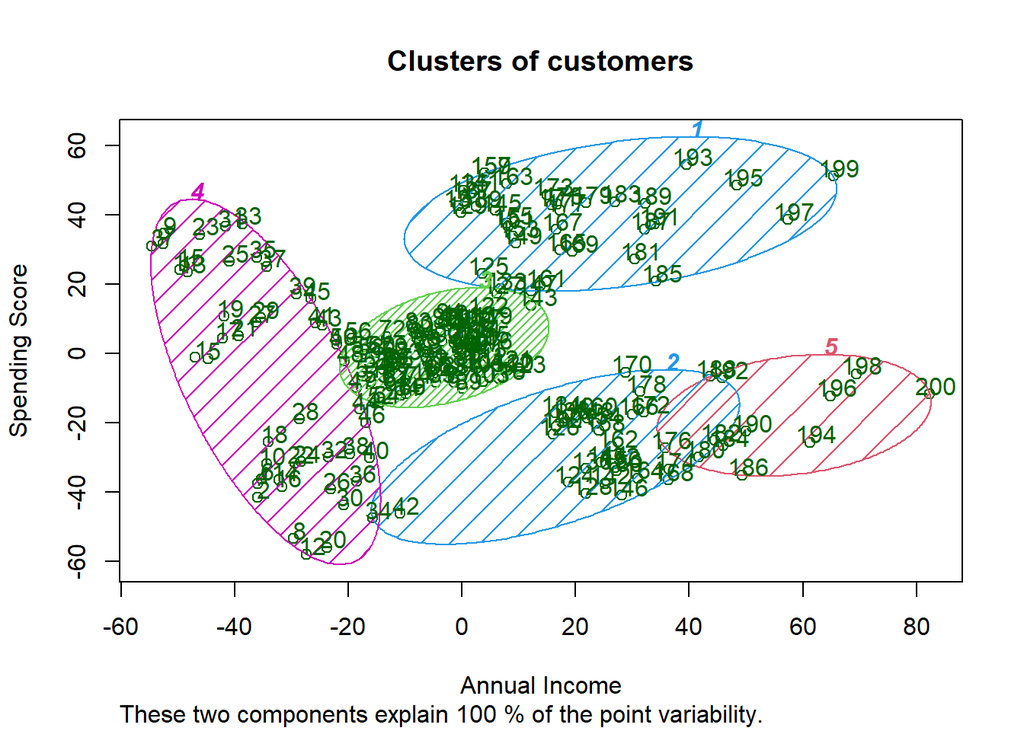

```r
set.seed(29)
ds = ds[4:5]
KM = kmeans(x=ds, centers=5)
y_KM = KM$cluster
clusplot(ds,
         y_KM,
         lines = 0,
         shade = TRUE,
         color = TRUE,
         labels = 2,
         plotchar = FALSE,
         span = TRUE,
         main = paste('Clusters of customers'),
         xlab = 'Annual Income',
         ylab = 'Spending Score')
```